# ChIP-Seq_analysis

juyoutai

2019/2/25

### ChIP-seq解析入門

このレポートではⅠ型古典的樹状細胞（cDC1）のIRF8に対するChIP-seqデータを解析していく. まずは必要なパッケージ群をインストールしよう. コメントアウトされたコマンドは初回のみ実行すれば良い.

```r
# install.packages("tidyverse")
# source("http://bioconductor.org/biocLite.R")
# BiocManager::install("ChIPpeakAnno")
# BiocManager::install("EnsDb.Mmusculus.v79")
# BiocManager::install("org.Mm.eg.db")
# BiocManager::install("BSgenome.Mmusculus.UCSC.mm10")
# BiocManager::install("rGADEM")
# BiocManager::install("Biostrings")
# BiocManager::install("MotIV")
# install.packages("ggseqlogo")
library(ChIPpeakAnno)
library(tidyverse)
library(EnsDb.Mmusculus.v79)
library(org.Mm.eg.db)
library(BSgenome.Mmusculus.UCSC.mm10)
library(rGADEM)
library(Biostrings)
library(MotIV)
library(ggseqlogo)

# set working directory where bed files are
setwd("~/Desktop/20190218_ChIP-seq/bed/")
```

## 遺伝子注釈（アノテーション）

現在ピークの情報（BEDファイル）はゲノム座標のみとなっている. ChIPpeakannoを用いてピークに遺伝子情報を付加する．またピークのゲノム上の位置も分かる．

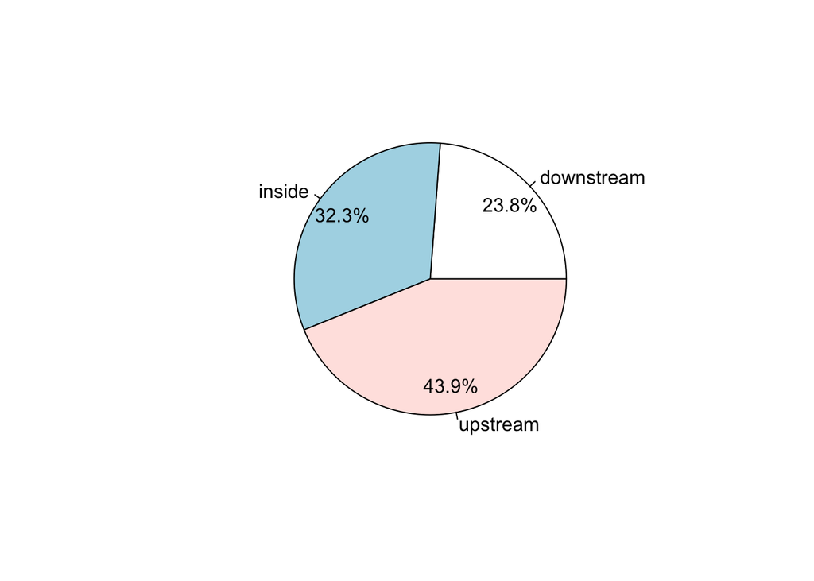

```r
# convert data type
path.cDC1.Irf8 <- "~/Desktop/20190218_ChIP-seq/bed/cDC1_IRF8_summits_light_40.bed"
gr.cDC1.Irf8 <- toGRanges(path.cDC1.Irf8, format="BED", header=FALSE)

# get ready for gene annotation
annoData <- toGRanges(EnsDb.Mmusculus.v79)
seqlevelsStyle(gr.cDC1.Irf8) <- seqlevelsStyle(annoData)

## do annotation by nearest TSS
anno <- annotatePeakInBatch(gr.cDC1.Irf8, AnnotationData = annoData)

# A pie chart can be used to demonstrate the overlap features of the peaks.
pie1(table(anno$insideFeature))
```

```r
# adding gene symbol
anno <- addGeneIDs(anno, orgAnn = "org.Mm.eg.db",
                   feature_id_type = "ensembl_gene_id",
                   IDs2Add = c("symbol"))
head(anno[1:5]) # gene symbol added
```

```
## GRanges object with 5 ranges and 11 metadata columns:
##                                          seqnames    ranges strand |
##                                             <Rle> <IRanges>  <Rle> |
##   cDC1_IRF8_peak_7761.ENSMUSG00000039452     chr9  66082179      * |
##   cDC1_IRF8_peak_6731.ENSMUSG00000085238     chr6 146675271      * |
##   cDC1_IRF8_peak_3700.ENSMUSG00000071042    chr17  75472517      * |
##   cDC1_IRF8_peak_4369.ENSMUSG00000035829     chr2  28402359      * |
##   cDC1_IRF8_peak_7634.ENSMUSG00000034908     chr9  45962023      * |
##                                              score                peak
##                                          <numeric>         <character>
##   cDC1_IRF8_peak_7761.ENSMUSG00000039452 157.73901 cDC1_IRF8_peak_7761
##   cDC1_IRF8_peak_6731.ENSMUSG00000085238 149.05202 cDC1_IRF8_peak_6731
##   cDC1_IRF8_peak_3700.ENSMUSG00000071042 137.63701 cDC1_IRF8_peak_3700
##   cDC1_IRF8_peak_4369.ENSMUSG00000035829 136.89536 cDC1_IRF8_peak_4369
##   cDC1_IRF8_peak_7634.ENSMUSG00000034908 134.49788 cDC1_IRF8_peak_7634
##                                                     feature start_position
##                                                 <character>      <integer>
##   cDC1_IRF8_peak_7761.ENSMUSG00000039452 ENSMUSG00000039452       66065176
##   cDC1_IRF8_peak_6731.ENSMUSG00000085238 ENSMUSG00000085238      146657218
##   cDC1_IRF8_peak_3700.ENSMUSG00000071042 ENSMUSG00000071042       75435905
##   cDC1_IRF8_peak_4369.ENSMUSG00000035829 ENSMUSG00000035829       28446800
##   cDC1_IRF8_peak_7634.ENSMUSG00000034908 ENSMUSG00000034908       45937857
##                                          end_position feature_strand
##                                             <integer>    <character>
##   cDC1_IRF8_peak_7761.ENSMUSG00000039452     66069731              -
##   cDC1_IRF8_peak_6731.ENSMUSG00000085238    146665403              +
##   cDC1_IRF8_peak_3700.ENSMUSG00000071042     75529043              +
##   cDC1_IRF8_peak_4369.ENSMUSG00000035829     28455508              +
##   cDC1_IRF8_peak_7634.ENSMUSG00000034908     45955247              -
##                                          insideFeature distancetoFeature
##                                               <factor>         <numeric>
##   cDC1_IRF8_peak_7761.ENSMUSG00000039452      upstream            -12448
##   cDC1_IRF8_peak_6731.ENSMUSG00000085238    downstream             18053
##   cDC1_IRF8_peak_3700.ENSMUSG00000071042        inside             36612
##   cDC1_IRF8_peak_4369.ENSMUSG00000035829      upstream            -44441
##   cDC1_IRF8_peak_7634.ENSMUSG00000034908      upstream             -6776
##                                          shortestDistance
##                                                 <integer>
##   cDC1_IRF8_peak_7761.ENSMUSG00000039452            12448
##   cDC1_IRF8_peak_6731.ENSMUSG00000085238             9868
##   cDC1_IRF8_peak_3700.ENSMUSG00000071042            36612
##   cDC1_IRF8_peak_4369.ENSMUSG00000035829            44441
##   cDC1_IRF8_peak_7634.ENSMUSG00000034908             6776
##                                          fromOverlappingOrNearest
##                                                       <character>
##   cDC1_IRF8_peak_7761.ENSMUSG00000039452          NearestLocation
##   cDC1_IRF8_peak_6731.ENSMUSG00000085238          NearestLocation
##   cDC1_IRF8_peak_3700.ENSMUSG00000071042          NearestLocation
##   cDC1_IRF8_peak_4369.ENSMUSG00000035829          NearestLocation
##   cDC1_IRF8_peak_7634.ENSMUSG00000034908          NearestLocation
##                                                 symbol
##                                            <character>
##   cDC1_IRF8_peak_7761.ENSMUSG00000039452         Snx22
##   cDC1_IRF8_peak_6731.ENSMUSG00000085238 4930479D17Rik
##   cDC1_IRF8_peak_3700.ENSMUSG00000071042       Rasgrp3
##   cDC1_IRF8_peak_4369.ENSMUSG00000035829       Ppp1r26
##   cDC1_IRF8_peak_7634.ENSMUSG00000034908         Sidt2
##   -------
##   seqinfo: 20 sequences from an unspecified genome; no seqlengths
```

```r
# export anootated data to txt file
write.table(anno, file = "cDC1.Irf8.annotation.txt")
# data <- read.delim("cDC1.Irf8.annotation.txt", sep = "")
```

## GO解析

GO解析はRでも可能だが, 少し煩雑なので今回はGUIで使えるwebサービス[GREAT](http://great.stanford.edu/public/html/)を使用する.

## モチーフ解析の準備：ピーク周辺配列

ピーク周辺の塩基配列をFASTAファイルに出力しよう.

```r
# Obtain the sequences around the peaks
seq <- getAllPeakSequence(gr.cDC1.Irf8,
                          upstream = 20,
                          downstream = 20,
                          genome = Mmusculus)
write2FASTA(seq, "20190225_test.fa")
```

## de novo モチーフ解析

rGADEMでモチーフ解析を実行しよう. 元のファイルだと相当な計算量だったが, ピーク領域を8分の1まで削ったのでかなり軽くなりました. やったね.

```r
## de novo motif analysis
# read FASTA file
cDC1.Irf8.seqs <- readDNAStringSet("20190225_test.fa", "fasta")
# do motif analysis
cDC1.Irf8.motif <- GADEM(cDC1.Irf8.seqs, verbose = T, genome = Mmusculus)
```

```
## *** Start C Programm ***
## ==============================================================================================
## input sequence file:
## number of sequences and average length:              957  41.0
## Use pgf method to approximate llr null distribution
## parameters estimated from sequences in:
##
## number of GA generations & population size:          5 100
##
## PWM score p-value cutoff for binding site declaration:       2.000000e-04
## ln(E-value) cutoff for motif declaration:            0.000000
##
## number of EM steps:                      40
## minimal no. sites considered for a motif:            47
##
## [a,c,g,t] frequencies in input data:             0.281203 0.218797 0.218797 0.281203
## ==============================================================================================
## *** Running an unseeded analysis ***
## GADEM cycle  1: enumerate and count k-mers... top 3  4, 5-mers: 20 40 60
## Done.
## Initializing GA... Done.
## GADEM cycle[  1] generation[  1] number of unique motif: 1
##    spacedDyad: cacttnnnnnnnntgact   motifConsensus: yrCTTTCAsTTCCyyywn    0.50 fitness: -1641.98
##
## GADEM cycle[  1] generation[  2] number of unique motif: 1
##    spacedDyad: cacttnnnnnnnntgact   motifConsensus: yrCTTTCAsTTCCyyywn    0.50 fitness: -1641.98
##
## GADEM cycle[  1] generation[  3] number of unique motif: 1
##    spacedDyad: actgannnnnnnnctttc   motifConsensus: rCTTTCAsTTCCyyywnn    0.60 fitness: -1645.53
##
## GADEM cycle[  1] generation[  4] number of unique motif: 1
##    spacedDyad: actgannnnnnnnctttc   motifConsensus: rCTTTCAsTTCCyyywnn    0.60 fitness: -1645.53
##
## GADEM cycle[  1] generation[  5] number of unique motif: 1
##    spacedDyad: actgannnnnnnnctttc   motifConsensus: rCTTTCAsTTCCyyywnn    0.60 fitness: -1645.53
##
## *** Running an unseeded analysis ***
## GADEM cycle  2: enumerate and count k-mers... top 3  4, 5-mers: 20 40 60
## Done.
## Initializing GA... Done.
```

[output cut: 47 more lines]

```
## Initializing GA... Done.
## GADEM cycle[  4] generation[  1] number of unique motif: 1
##    spacedDyad: tganngaaa            motifConsensus: GAAGwGAAA             0.10 fitness:   22.92
##
## GADEM cycle[  4] generation[  2] number of unique motif: 1
##    spacedDyad: tganngaaa            motifConsensus: GAAGwGAAA             0.10 fitness:   22.92
##
## GADEM cycle[  4] generation[  3] number of unique motif: 1
##    spacedDyad: tganngaaa            motifConsensus: GAAGwGAAA             0.10 fitness:   22.92
##
## GADEM cycle[  4] generation[  4] number of unique motif: 1
##    spacedDyad: tganngaaa            motifConsensus: GAAGwGAAA             0.10 fitness:   22.92
##
## GADEM cycle[  4] generation[  5] number of unique motif: 1
##    spacedDyad: tganngaaa            motifConsensus: GAAGwGAAA             0.10 fitness:   22.92
```

```r
# how many motifs detected?
nMotifs(cDC1.Irf8.motif)
```

```
## [1] 4
```

```r
# get consensus sequences
consensus(cDC1.Irf8.motif)
```

```
## [1] "rCTTTCAsTTCCy"   "AsTCAwAnnGAAAGn" "nrGGAAsTGr"      "sTTCykCTTyyn"
```

```r
# get PWM
cDC1.Irf8.PWM <- getPWM(cDC1.Irf8.motif)
```

## 既知モチーフと照合

得られた配列を既知モチーフのDBと照合して見ましょう．こ子で得られるのはあくまで既知モチーフとの類似度なので, 実際の配列を自分の目で判断する必要あります.まだ報告されていないモチーフが検出されるかもしれない!

```r
path <- system.file(package = "MotIV")
jaspar <- readPWMfile(paste(path, "/extdata/jaspar2010.txt", sep = ""))
jaspar.scores <- readDBScores(paste(path, "/extdata/jaspar2010_PCC_SWU.scores", sep = ""))

# search motifs
cDC1.Irf8.jaspar <- motifMatch(
  inputPWM = cDC1.Irf8.PWM,
  align = "SWU",
  cc    = "PCC",
  database = jaspar,
  DBscores = jaspar.scores,
  top = 5
)
```

```
##
##  Ungapped Alignment
##  Scores read
##  Database read
##  Motif matches : 5
```

```r
summary(cDC1.Irf8.jaspar)
```

```
##  Number of input motifs :  4
##  Input motifs names :  ACTTTCACTTTGA TGTCATACTGTGAGC GAGGAATTGA CTTCTTTCTCTG
##  Number of matches per motif:  5
##  Matches repartition :
##         IRF1         SPI1         ELK4          FEV        GABPA
##            3            3            2            2            2
##         IRF2         ELF5        HNF1A        HNF1B NFE2L1::MafG
##            2            1            1            1            1
##         Sox2         SPIB
##            1            1
##  Arguments used :
##    -metric name :  PCC
##    -alignment :  SWU
```

```r
viewAlignments(cDC1.Irf8.jaspar)[[1]]
```

```
##        IRF1            IRF2                 SPI1
## seq    "RCTTTCASTTCCN" "-----RCTTTCASTTCCN" "RCTTTCASTTCCN"
## match  "GGTTTCRNTTTN-" "NNWWNRSTTTCRCTTTCS" "------ACTTCCT"
## evalue "4.8791e-08"    "5.3173e-07"         "1.591e-05"
##        GABPA            ELK4
## seq    "RCTTTCASTTCCN-" "RCTTTCASTTCCN--"
## match  "---NNCACTTCCGG" "------ACTTCCGGT"
## evalue "1.4317e-04"     "1.9312e-03"
```

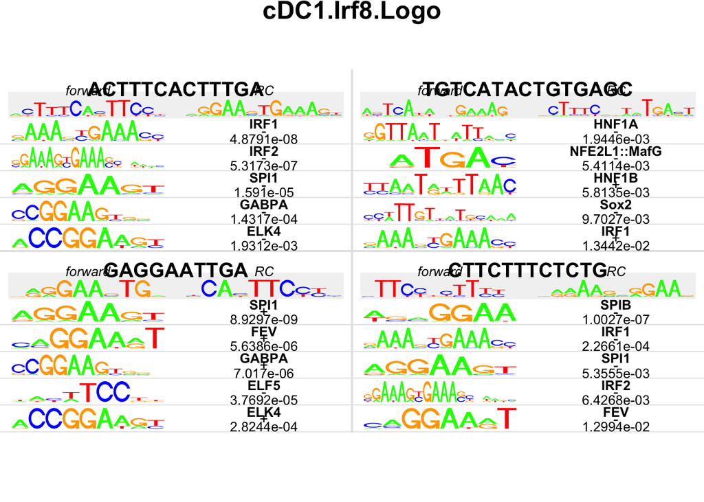

```r
plot(cDC1.Irf8.jaspar[1:4],ncol=2,top=5, cex=0.8, main = "cDC1.Irf8.Logo")
```

## モチーフ可視化

デフォルトのseqLogoは目がチカチカするので（特にアデニン）気に入らない。 目に優しくかつggplot2でsequence logoを描画できるggseqlogoを採用する（Aが落ち着いた色になったね！）。ggplot2の要領で図に色々と書き込める点も便利！時代はtidyverse！kれからはggseqlogoパッケージでtidyなseqLogoを描いていこう．

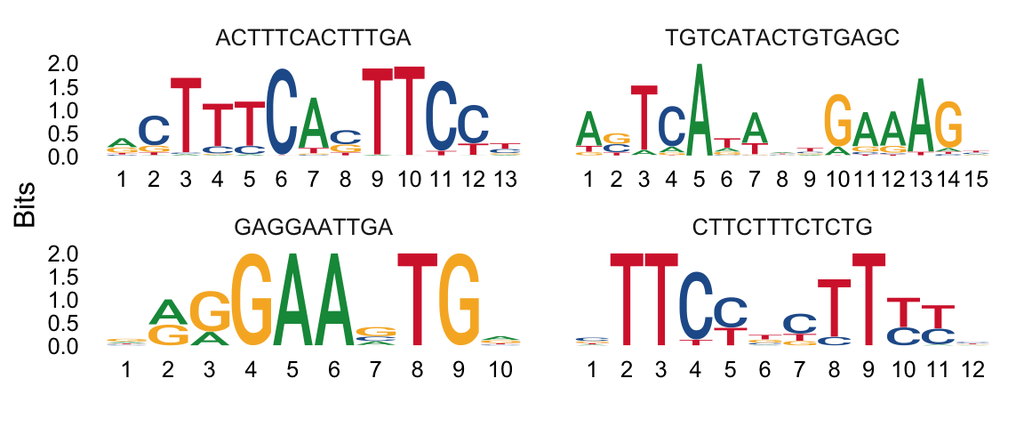

```r
# visualise with ggseqlogo
ggseqlogo(cDC1.Irf8.PWM[1:4])
```

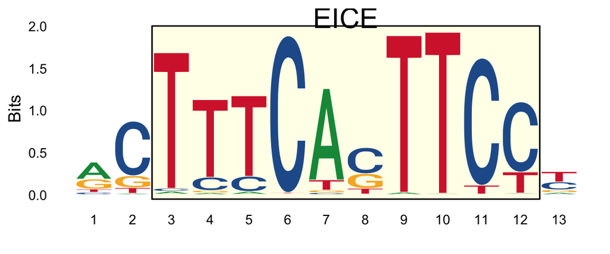

```r
p1 <- ggplot() +
  annotate('rect', xmin = 2.5, xmax = 12.5, ymin = -0.05, ymax = 2, alpha = .1, col='black', fill='yellow') +
  geom_logo(cDC1.Irf8.PWM[1], stack_width = 0.90) +
  annotate('text', x=7.5, y=2.1, label='EICE', size = 7, colour = "black") +
  theme_logo()
p1
```

お疲れ様でした. なかなか大変でしたね.

## ngs.plotでリード分布を可視化

Bioconductorには簡単に綺麗なヒートマップを描画するパッケージがなかったので, 今回はコマンドラインツールのngs.plotを使用する. 中身はRとpythonか. このツールはなかなかの優れものでいろいろなことができる. 初回はngs.plotにPATHを通し, 環境変数NGSPLOTを定義してやる必要がある.

結構な計算量なので結果のみ載せる.

```bash
cd ~/Desktop/ngsplot
export PATH=$PATH:~/Desktop/ngsplot/ngsplot/bin/
export NGSPLOT=~/Desktop/ngsplot/ngsplot
source ~/.bash_profile
# excute ngs,plot
ngs.plot.r -G mm10 -R genebody -C list.txt -O cDC1vscDC2 -L 4000 -FL 300
pwd
```

結果、このようなplotが得られる

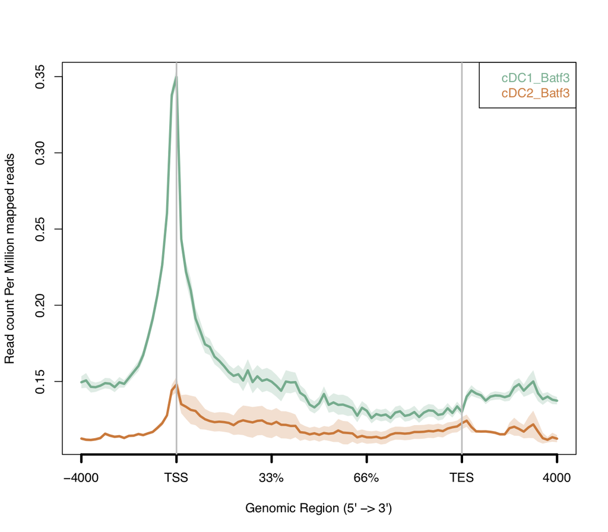

Batf3はどういった分布を示すか？ちなみにcDC1/2の両者でBatf3は非常に高発現している。なぜこの様な差が生まれるのか？